# A5 Index

Ryan Leung

May 4, 2019

## Summary Information

[original data source](https://www.gunviolencearchive.org/reports/mass-shooting)

Within the mass shooting dataset, there are 340 shootings. The total number killed is 373, and the city most impacted by mass shootings is Chicago. Most impacted is defined as most number of injuries occurred within a city. The average amount of deaths per mass shooting is 1.0970588 deaths, and the most number of injuries for a given shooting is 19.

## Summary Table

| state | total_killed | total_injured |
| --- | --- | --- |
| California | 50 | 136 |
| Illinois | 21 | 150 |
| Michigan | 10 | 28 |
| New York | 5 | 53 |

## Shooting Incident in New Orleans | May 2018

On May 1, 2018, there was a [shooting](https://www.nola.com/crime/2018/05/last_straw_hours_after_5_shot.html) in New Orleans, Louisiana. The shooting left 5 people injured and 0 deaths. From the article,  
it was said that a local resident had been wanting to move away from the neghborhood due to already high crime rate. All the victims were  
sent to the hospital.

## Interactive Map

This interactive map displays all the mass shootings that occurred in the U.S. based on the mass shootings data set.

[interactive chart not shown]

## State vs Number of Injured Graph

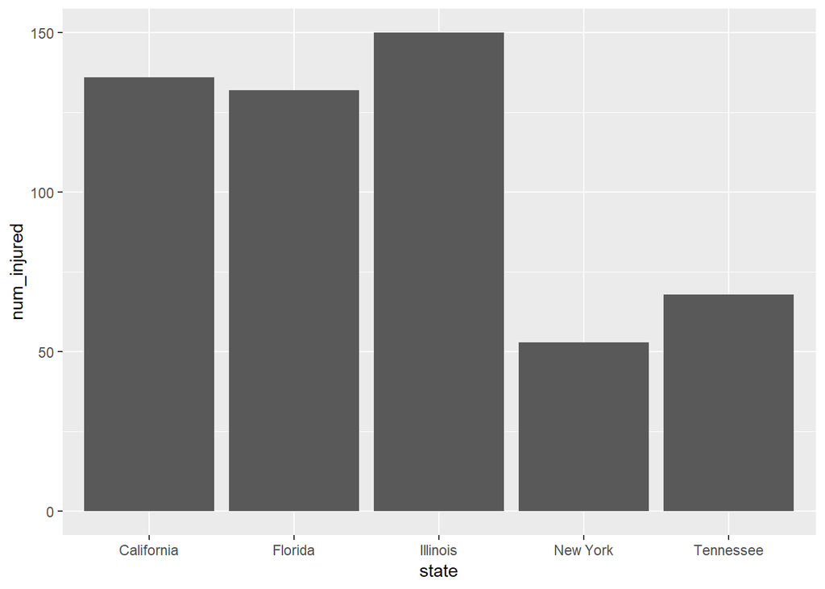

- I chose these states because they’re in the centers of majority of shootings.
- California, Florida, and Illinois have +100 injuries caused by shootings.
- New York and Tennesse have less than 100 injuries caused by shootings.